# Aula 3 - Estágio Supervisionado II

Filipe Duarte

8/14/2019

# Aula 3

Nesta aula veremos como estimar os parâmetros das distribuições pelo método da máxima verossimilhança. Em seguida, aprenderemos como selecionar o modelo com o melhor ajuste para a amostra.

## Método da Máxima Verossimilhança

O método da máxima verossimilhança é um método para estimar os parâmetros de um modelo probabilístico. Dessa maneira, dada uma amostra e dado um modelo probabilístico, a estimativa por máxima verossimilhança estima os valores para os diferentes parâmetros do modelo.

Considerando $X$ uma variável aleatória e sendo $f(x,\theta)$ a função de densidade, onde o parâmetro $\theta$ é desconhecido. Dessa forma, dada uma amostra aleatória simples de $X$,de tamanho $n$, $X_1, X_2, ..., X_n$, e sejam $x_1, x_2, ..., x_n$ os valores observados, a função de verossimilhança $L$ define-se por:

$$L(\theta; x_1,..., x_n) = f(x_1;\theta)*...*f(x_n;\theta).$$

Dessa forma, dizemos que $\hat{\theta}$ é um estimador de máxima verossimilhança (EMV) para $\theta = \theta_0$.

## fitditsrplus

O pacote `fitdistrplus` estima os parâmetros dos modelos pela máxima verossimilhança. Portanto, faremos uso dessa técnica para estimar os parâmetros dos modelos para os dados dos sinistros.

Carregando biblioteca:

```r
library(fitdistrplus)
```

Carregando dados:

```r
sinistro <- read.csv("sinistros.csv", header = TRUE, sep=",")
```

Visualizando os dados:

```r
head(sinistro)
```

```
##   X          x
## 1 1  172.28719
## 2 2  242.73857
## 3 3  445.94377
## 4 4  815.13975
## 5 5 1302.07868
## 6 6   90.00823
```

Criando um vetor apenas com os valores dos sinistros:

```r
sinistro <- sinistro$x
```

Estatísticas descritivas:

```r
# summary
summary(sinistro)
```

```
##    Min. 1st Qu.  Median    Mean 3rd Qu.    Max.
##   12.11  216.65  441.26  535.30  796.66 1818.77
```

```r
# desvio padrão
sd(sinistro)
```

```
## [1] 410.4036
```

Histograma

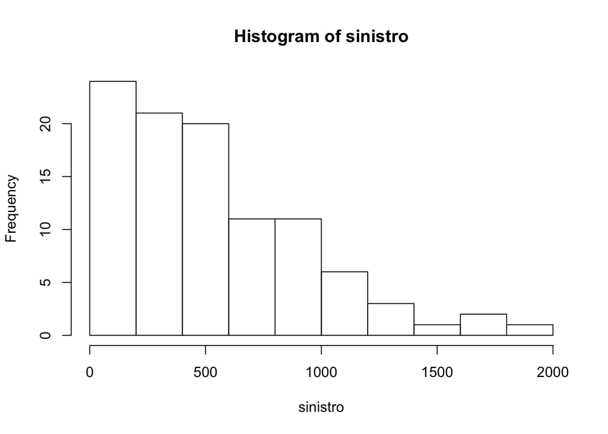

```r
# histograma
hist(sinistro)
```

# Ajuste das distribuições

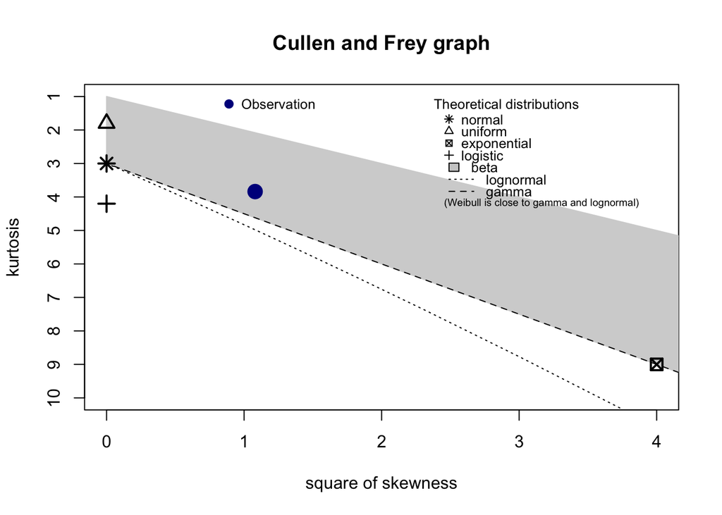

```
## summary statistics
## ------
## min:  12.11001   max:  1818.766
## median:  441.2607
## mean:  535.2991
## estimated sd:  410.4036
## estimated skewness:  1.039267
## estimated kurtosis:  3.838951
```

```r
descdist(sinistro)
```

Vamos testar para gamma, weibull e lognormal:

```r
fit <- fitdist(sinistro, "gamma")
fitdist(sinistro, "weibull")
```

```
## Fitting of the distribution ' weibull ' by maximum likelihood
## Parameters:
##         estimate Std. Error
## shape   1.281123  0.1020256
## scale 577.074872 47.3792335
```

```r
fitdist(sinistro, "lnorm")
```

```
## Fitting of the distribution ' lnorm ' by maximum likelihood
## Parameters:
##         estimate Std. Error
## meanlog 5.896328 0.10208724
## sdlog   1.020872 0.07218627
```

Vamos plotar o histograma com a curva gerada a partir da estimação:

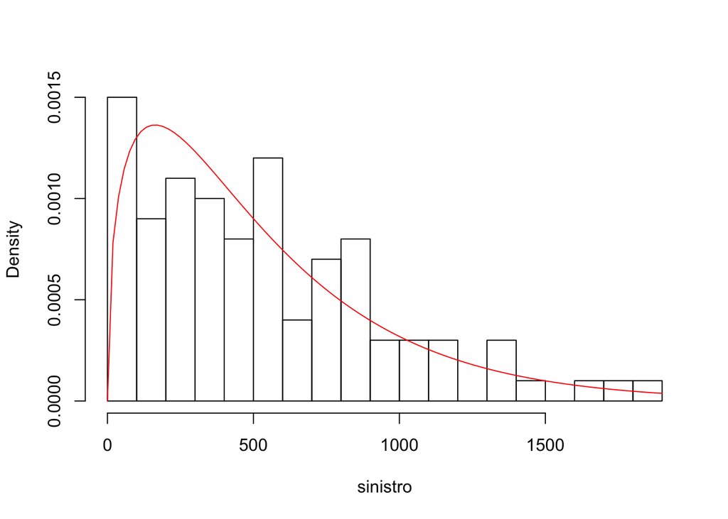

```r
hist(sinistro, pch=20, breaks = 20, prob = TRUE, main = "")
curve(dgamma(x, fit$estimate[1], fit$estimate[2]), add = TRUE, col = "red")
```

Vamos fazer o histograma e a distribuição acumulada:

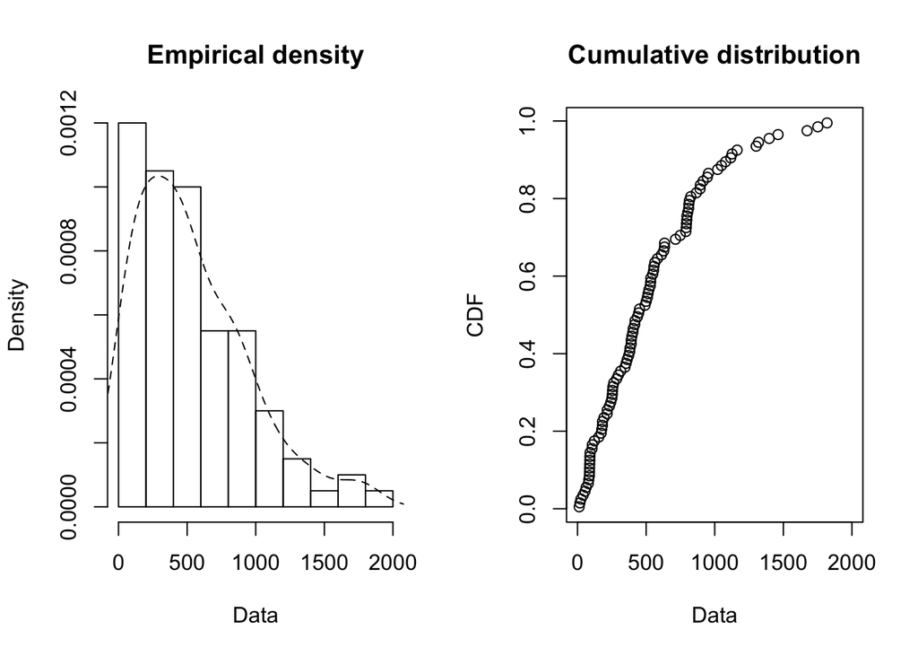

```r
plotdist(sinistro, histo = TRUE, demp = TRUE)
```

Agora vamos estimar novamente para criar as 3 funções

```r
fit_w  <- fitdist(sinistro, "weibull")
fit_g  <- fitdist(sinistro, "gamma")
fit_ln <- fitdist(sinistro, "lnorm")
```

```r
summary(fit_w)
```

```
## Fitting of the distribution ' weibull ' by maximum likelihood
## Parameters :
##         estimate Std. Error
## shape   1.281123  0.1020256
## scale 577.074872 47.3792335
## Loglikelihood:  -723.9747   AIC:  1451.949   BIC:  1457.16
## Correlation matrix:
##           shape     scale
## shape 1.0000000 0.3092276
## scale 0.3092276 1.0000000
```

```r
summary(fit_g)
```

```
## Fitting of the distribution ' gamma ' by maximum likelihood
## Parameters :
##          estimate   Std. Error
## shape 1.437275405 0.1469102032
## rate  0.002684913 0.0002710074
## Loglikelihood:  -724.6539   AIC:  1453.308   BIC:  1458.518
## Correlation matrix:
##           shape      rate
## shape 1.0000000 0.7292785
## rate  0.7292785 1.0000000
```

```r
summary(fit_ln)
```

```
## Fitting of the distribution ' lnorm ' by maximum likelihood
## Parameters :
##         estimate Std. Error
## meanlog 5.896328 0.10208724
## sdlog   1.020872 0.07218627
## Loglikelihood:  -733.5924   AIC:  1471.185   BIC:  1476.395
## Correlation matrix:
##         meanlog sdlog
## meanlog       1     0
## sdlog         0     1
```

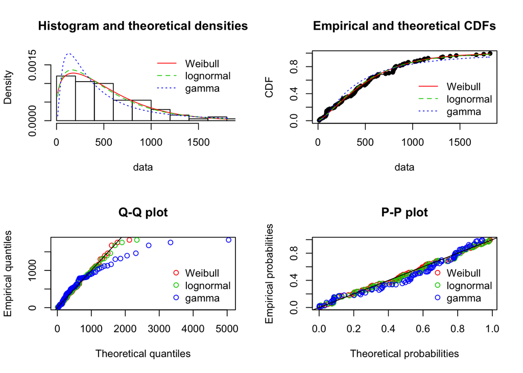

```r
par(mfrow=c(2,2))
plot.legend <- c("Weibull", "lognormal", "gamma")
denscomp(list(fit_w, fit_g, fit_ln), legendtext = plot.legend)
cdfcomp (list(fit_w, fit_g, fit_ln), legendtext = plot.legend)
qqcomp  (list(fit_w, fit_g, fit_ln), legendtext = plot.legend)
ppcomp  (list(fit_w, fit_g, fit_ln), legendtext = plot.legend)
```

Testando outras distribuições:

Carregar outro pacote:

```r
library(actuar)
```

Testando a loglogistica e pareto:

```r
fit_ll <- fitdist(sinistro, "llogis", start = list(shape = 1, scale = 500))
fit_P  <- fitdist(sinistro, "pareto", start = list(shape = 1, scale = 500))
summary(fit_ll)
```

```
## Fitting of the distribution ' llogis ' by maximum likelihood
## Parameters :
##         estimate Std. Error
## shape   1.767883  0.1479838
## scale 403.496047 39.7062313
## Loglikelihood:  -732.5704   AIC:  1469.141   BIC:  1474.351
## Correlation matrix:
##           shape     scale
## shape 1.0000000 0.0828307
## scale 0.0828307 1.0000000
```

```r
summary(fit_P)
```

```
## Fitting of the distribution ' pareto ' by maximum likelihood
## Parameters :
##         estimate Std. Error
## shape    3975888          0
## scale 2128593624        NaN
## Loglikelihood:  -728.2826   AIC:  1460.565   BIC:  1465.775
## Correlation matrix:
##       shape scale
## shape     1   NaN
## scale   NaN     1
```

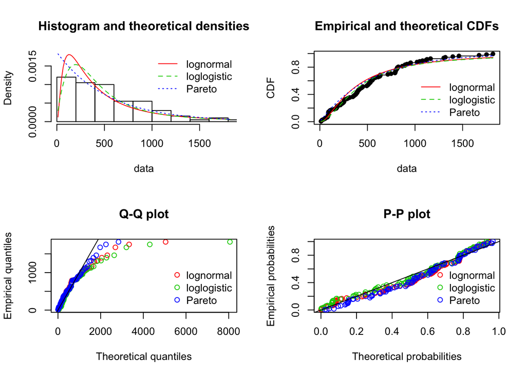

```r
par(mfrow=c(2,2))
plot.legend <- c("lognormal", "loglogistic", "Pareto")
denscomp(list(fit_ln, fit_ll, fit_P), legendtext = plot.legend)
cdfcomp (list(fit_ln, fit_ll, fit_P), legendtext = plot.legend)
qqcomp  (list(fit_ln, fit_ll, fit_P), legendtext = plot.legend)
ppcomp  (list(fit_ln, fit_ll, fit_P), legendtext = plot.legend)
```

```r
gofstat(list(fit_w, fit_g, fit_ln, fit_ll, fit_P), fitnames = c("Weibull","Gama","LogNormal", "Loglogística", "Pareto"))
```

```
## Goodness-of-fit statistics
##                                 Weibull       Gama LogNormal Loglogística
## Kolmogorov-Smirnov statistic 0.06571761 0.06957658 0.1202205   0.08212615
## Cramer-von Mises statistic   0.04851234 0.07507705 0.3234141   0.16308113
## Anderson-Darling statistic   0.33360591 0.45952562 1.8945669   1.41603928
##                                 Pareto
## Kolmogorov-Smirnov statistic 0.1157534
## Cramer-von Mises statistic   0.3195346
## Anderson-Darling statistic   1.7619729
##
## Goodness-of-fit criteria
##                                 Weibull     Gama LogNormal Loglogística
## Akaike's Information Criterion 1451.949 1453.308  1471.185     1469.141
## Bayesian Information Criterion 1457.160 1458.518  1476.395     1474.351
##                                  Pareto
## Akaike's Information Criterion 1460.565
## Bayesian Information Criterion 1465.775
```